# sidtoolbox_onearm

# Subgroup discovery demonstration

## Simulated data

```r
# simulate a sample dataset with 3 types of variables, numeric, binary, and count
# covariates are X1, X2, ...
# outcomes are Y_[type], namely Y_numeric, Y_binary, and Y_count
# the contrast arm is TRT
# 'N' samples will be created
# also places two subgroups, oneis true positive (random_TP) of size 'subgroup_ratio'*'N' where the treatment arm is enhanced by 'subgroup_enhanced_effect'
# and false positive (random_FP) of same size but where both arms are shifted by 'subgroup_shift_effect'
subgroup.data <- simulateSubgroupData(
                            N = 2000,
                            case = "prognostic",
                            arm = "one",
                            overal_treatment_effect = 0.5,
                            subgroup_enhanced_effect = 1.5,
                            subgroup_ratio = 0.1,
                            covariates_normal = list(c(0,1), c(0,1), c(0,1)),
                            correlation = c(),
                            covariates_binary = c(0.5, 0.5, 0.5, 0.5),
                            covariates_uniform = list(c(0,1), c(0,1), c(0,1)),
                            has_FP = TRUE,
                            SD_NOISE_RATIO = 0.1)
```

```
## [1] "Simulating one arm study"
## [1] "Loading one arm study"
```

```r
# to load your own data use loadDataset function
# you would need to set your covariates and outcomes.
# for one arm study do not set the contrast parameter.
#loadDataset(dataset = subgroup.data,
#            covariates = subgroup.data$covariates,
#            outcomes = subgroup.data$outcomes,
#            outcomeTypes = subgroup.data$outcomeTypes)
```

Then set some global variables. The minimum size of a subgroup to be found, how deep the rules can go, the significance threshold, and the smallest value for p-value to avoid underflow.

```r
SUBGROUP_MIN_SIZE <- 0.1
MAX_DEPTH <- 2
P_THRESHOLD <- 0.05
MIN_P_VALUE <- 10^-10 # to avoid underflow
```

## Explore the data

This step helps identify covariates to be included in the subgroup discovery.

### Correlation matrix

Correlations who one on one relation in your data. Highly correlated covariates should be removed. Here we get the corrlation between numeric features.

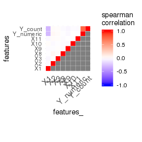

```r
# examples
exploreTriangleCorrelationMatrix(subgroup.data = subgroup.data, method = "spearman")
```

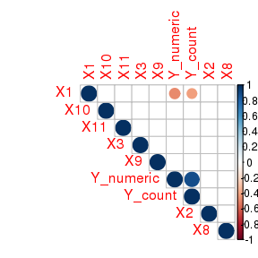

```r
exploreCorrelationMatrix(subgroup.data = subgroup.data)
```

[figure not shown]

```r
exploreDetailedChartCorrelation(subgroup.data = subgroup.data)
```

### Association rules

Association rules help us find high level correlations in the data. The rules are controled by support (how large the corresponding subgroup is) and confidence (how many of the total subgroup size follow the rule).

Association rules are defined by support and confidence. Support shows us how frequently the rule (left hand side) is in the data, similar to subgroup size. Confidence is the number of times the rule is correct (right hand side | left hand side), and thus is a measure of strength for the rule. The minimum and maximum depth of the rule can be set by min_order and max_order.

By filtering RHS (right hand side) for the outcome variables you can find immediate subgroups with highest support.

```r
# res <- exploreAssociationRules(subgroup.data)
min_support <- 0.1 # how many samples support the LHS
min_confidence <- 0.5 # how many times RHS | LHS is true
min_order <- 2 # minimum depth of rules
max_order <- 4 # maximum depth of rules
paste("minimum support =", min_support,
      "minimum confidence =", min_confidence,
      "minimum depth =", min_order,
      "maximum depth =", max_order)
```

```
## [1] "minimum support = 0.1 minimum confidence = 0.5 minimum depth = 2 maximum depth = 4"
```

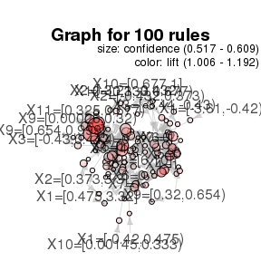

```r
a <- capture.output(p <- plotAssociationRules(subgroup.data = subgroup.data, onlyCovariates = TRUE, support = min_support, confidence = min_confidence, min_order = min_order, max_order = max_order))
```

```r
p
```

```
## IGRAPH DN-- 125 260 --
## + attr: name (v/c), label (v/c), support (v/n), confidence (v/n),
## | lift (v/n), count (v/n), order (v/n)
## + edges (vertex names):
##  [1] 6 ->assoc1  14->assoc2  10->assoc3  20->assoc3  13->assoc4
##  [6] 19->assoc4  10->assoc5  12->assoc5  17->assoc6  11->assoc7
## [11] 17->assoc7  7 ->assoc8  4 ->assoc9  23->assoc10 10->assoc11
## [16] 19->assoc11 12->assoc12 11->assoc13 14->assoc13 19->assoc14
## [21] 16->assoc15 20->assoc15 11->assoc16 12->assoc16 15->assoc17
## [26] 17->assoc17 15->assoc18 19->assoc19 12->assoc20 19->assoc20
## [31] 12->assoc21 17->assoc21 2 ->assoc22 22->assoc23 14->assoc24
## + ... omitted several edges
```

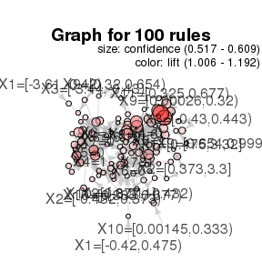

```r
a <- capture.output(p <- plotAssociationRules(subgroup.data = subgroup.data, method = "graph", measure = "confidence", onlyCovariates = TRUE, support = min_support, confidence = min_confidence, min_order = min_order, max_order = max_order))
```

```r
p
```

```
## IGRAPH DN-- 125 260 --
## + attr: name (v/c), label (v/c), support (v/n), confidence (v/n),
## | lift (v/n), count (v/n), order (v/n)
## + edges (vertex names):
##  [1] 6 ->assoc1  14->assoc2  10->assoc3  20->assoc3  13->assoc4
##  [6] 19->assoc4  10->assoc5  12->assoc5  17->assoc6  11->assoc7
## [11] 17->assoc7  7 ->assoc8  4 ->assoc9  23->assoc10 10->assoc11
## [16] 19->assoc11 12->assoc12 11->assoc13 14->assoc13 19->assoc14
## [21] 16->assoc15 20->assoc15 11->assoc16 12->assoc16 15->assoc17
## [26] 17->assoc17 15->assoc18 19->assoc19 12->assoc20 19->assoc20
## [31] 12->assoc21 17->assoc21 2 ->assoc22 22->assoc23 14->assoc24
## + ... omitted several edges
```

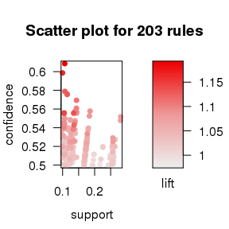

```r
a <- capture.output(p <- plotAssociationRules(subgroup.data = subgroup.data, method = "scatterplot", measure = "support", onlyCovariates = TRUE, support = min_support, confidence = min_confidence, min_order = min_order, max_order = max_order))
```

```r
p
```

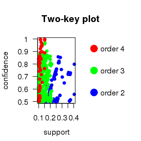

```r
a <- capture.output(p <- plotAssociationRules(subgroup.data = subgroup.data, method = "two-key plot", measure = "support", onlyCovariates = FALSE, support = min_support, confidence = min_confidence, min_order = min_order, max_order = max_order))
```

```r
p
```

```r
#plotAssociationRulesInteractive(subgroup.data = subgroup.data, onlyCovariates = TRUE)
a <- capture.output(rules <- listAssociationRules(subgroup.data = subgroup.data, onlyCovariates = FALSE, support = min_support, confidence = min_confidence, min_order = min_order, max_order = max_order))

as.data.table(rules)
```

```
##                                LHS          RHS support confidence
##   1:                        {X6=1} {Y_binary=0}  0.4045  0.7978304
##   2:                  {Y_binary=0}       {X6=1}  0.4045  0.5590878
##   3:                        {X5=1} {Y_binary=0}  0.3715  0.7277179
##   4:                  {Y_binary=0}       {X5=1}  0.3715  0.5134762
##   5:                        {X4=0} {Y_binary=0}  0.3680  0.7159533
##  ---
## 831:      {X4=0,X9=[0.00026,0.32)}       {X5=1}  0.1000  0.5376344
## 832:        {X5=0,Y_count=[15,25)}       {X6=1}  0.1000  0.6042296
## 833: {Y_binary=0,Y_count=[25,250]}       {X6=0}  0.1000  0.5509642
## 834:       {X5=1,Y_count=[25,250]}       {X4=0}  0.1000  0.5586592
## 835:       {X4=0,Y_count=[25,250]}       {X5=1}  0.1000  0.5479452
##           lift count
##   1: 1.1027372   809
##   2: 1.1027372   809
##   3: 1.0058299   743
##   4: 1.0058299   743
##   5: 0.9895692   736
##  ---
## 831: 1.0531526   200
## 832: 1.1917744   200
## 833: 1.1175744   200
## 834: 1.0868856   200
## 835: 1.0733501   200
```

### Conditional inference tree

Conditional inference trees are supervised trees useful to find different subgroups. In a one arm study, the leaves can be intrepreted as subgroups. You can see one tree for each outcome.

**Be cautious when intrepreting the survival data as the values will be treated as numeric.**

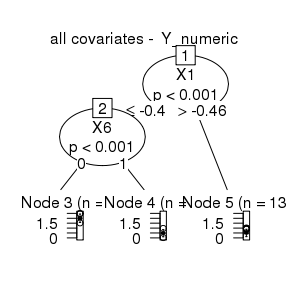

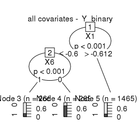

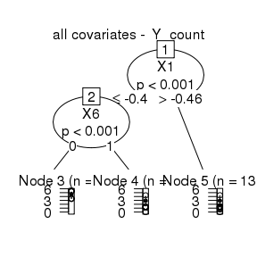

```r
# on all coavriates
a <- lapply(X = subgroup.data$outcomes, FUN = function(y) {
  capture.output(p <- exploreConditionalInferenceTree(subgroup.data = subgroup.data, y_idx = y, stump = FALSE, testtype = "Bonferroni", significance = P_THRESHOLD, nmin = SUBGROUP_MIN_SIZE, maxdepth = MAX_DEPTH))
  plot(main = paste("all covariates - ", colnames(subgroup.data$data)[y]), p)
})
```

You can use the above information to filter down your features. User knowledge is required to decide which features to eliminate. Note that correlated features will cause errors in the downstream analysis.

## Subgroup discovery

Let us discover some subgroups.

```r
# set the outcomes you want to run subgroup discovery on
outcome_columns <- colnames(subgroup.data$data)[subgroup.data$outcomes]
# save all rules in allRules
allRules <- subgroup.data$rules
allRules
```

```
##                   rule method outcome   desc                       param
## 1: X1 <= -0.46, X6 = 0 sim_TP         random depth 2, subgroup_ratio 0.1
## 2:      X7 = 1, X8 > 6 sim_FP         random depth 2, subgroup_ratio 0.1
```

### Treatment-specific Subgroup Discovery Tool (TSDT)

**Battioui, C., Shen, L., Ruberg, S., (2014). *A Resampling-based Ensemble Tree Method to Identify Patient Subgroups with Enhanced Treatment Effect.* JSM proceedings, 2014**

Increase the number of CPU cores according to your machine. Increase the sample and permutation in a real world study to at least 100 and 100. The suggested setting by authors is 100 and 500.

Caution: TSDT does not have a built-in model for count data. It assumes it is numeric, and the package adds log transformation on it.

```r
# the true positive / false positive subgroup is
# subgroup.data$rules

param <- list(
  desirable_response = "increasing",
  nsamples = 100,
  npermutations = 100, # increase the permutation in a real world study
  maxdepth = MAX_DEPTH,
  min_subgroup_n_control = SUBGROUP_MIN_SIZE/2,
  min_subgroup_n_trt = SUBGROUP_MIN_SIZE/2,
  n_cpu = 1 # increase the number of CPU cores according to your machine
)

resTSDT <- lapply(X = outcome_columns, FUN = function(y_idx) {
  res <- runTSDT(subgroup.data = subgroup.data,
                     y_idx = y_idx,
                     desirable_response = param$desirable_response,
                     nsamples = param$nsamples,
                     npermutations = param$npermutations,
                     maxdepth = param$maxdepth,
                     n_cpu = param$n_cpu)
  allRules <<- rbind(allRules,
                    parseTSDTResults(TSDT_table = res, outcome = y_idx, param = param, filter = "Strong"))
  return(res)
})
```

```
## [1] "numeric"
```

[output not shown]

[output cut: 46 more lines]

[output not shown]

[output not shown]

[output cut: 46 more lines]

[output not shown]

[output not shown]

[output cut: 45 more lines]

[output not shown]

```r
resTSDT
```

```
## [[1]]
##                    Subgroup Internal_Consistency External_Consistency
##  1:                 Overall                   NA                   NA
##  2:                X1<xxxxx                 1.00            1.0000000
##  3: X1<xxxxx & X6%in%c('0')                 1.00            1.0000000
##  4:            X6%in%c('0')                 1.00            1.0000000
##  5:               X2>=xxxxx                 0.17            0.8235294
##  6:                X8<xxxxx                 0.13            0.6153846
##  7:                X9<xxxxx                 0.17            0.2352941
##  8:               X10<xxxxx                 0.11            0.2727273
##  9:               X3>=xxxxx                 0.05            0.2000000
## 10:                X3<xxxxx                 0.08            0.0000000
## 11:             dummy<xxxxx                 0.07            0.0000000
## 12:                X2<xxxxx                 0.06            0.0000000
## 13:               X11<xxxxx                 0.04            0.0000000
```

[output cut: 198 more lines]

### Optimization approach with Particle Swarm Optimization (PSO)

PSO searches for optimal cutoffs while leaxing for p-value and depth. You can define your own function or use the default model: **effect size: Y ~ subgroup for one-arm** and interaction effect size: Y ~ contrast + subgroup + contrast*subgroup for two-arm.

Use larger iteration numbers for larger datasets. 1000 should suffice for up to 100 covariates.

```r
# increasing
resPSO <- lapply(X = outcome_columns,
                 FUN = function(y_idx){
  pso <- runPSO(subgroup.data = subgroup.data,
                y_idx = y_idx,
                desirable_response = "increasing",
                depth = MAX_DEPTH,
                nmin = SUBGROUP_MIN_SIZE,
                iterations = 1000)
  allRules <<- rbind(allRules,
                     pso)
  pso
})
```

```
## S=40, K=3, p=0.07314, w0=0.7213, w1=0.7213, c.p=1.193, c.g=1.193
```

```
## v.max=NA, d=9.381, vectorize=TRUE, hybrid=off
```

```
## It 10: fitness=-1.468
```

```
## It 20: fitness=-1.776
```

```
## It 30: fitness=-1.776
```

```
## It 40: fitness=-1.823
```

```
## It 50: fitness=-2.469
```

```
## It 60: fitness=-2.495
```

```
## It 70: fitness=-2.503
```

```
## It 80: fitness=-2.503
```

```
## It 90: fitness=-2.503
```

```
## It 100: fitness=-2.503
```

```
## It 110: fitness=-2.503
```

```
## It 120: fitness=-2.503
```

```
## It 130: fitness=-2.503
```

```
## It 140: fitness=-2.503
```

```
## It 150: fitness=-2.503
```

```
## It 160: fitness=-2.503
```

```
## It 170: fitness=-2.503
```

```
## Maximal number of iterations without improvement reached
```

```
## S=40, K=3, p=0.07314, w0=0.7213, w1=0.7213, c.p=1.193, c.g=1.193
```

```
## v.max=NA, d=9.381, vectorize=TRUE, hybrid=off
```

```
## It 10: fitness=-3.514
```

```
## It 20: fitness=-3.558
```

```
## It 30: fitness=-3.671
```

```
## It 40: fitness=-3.693
```

```
## It 50: fitness=-3.701
```

```
## It 60: fitness=-3.701
```

```
## It 70: fitness=-3.701
```

```
## It 80: fitness=-3.701
```

```
## It 90: fitness=-3.701
```

```
## It 100: fitness=-3.701
```

```
## It 110: fitness=-3.701
```

```
## It 120: fitness=-3.701
```

```
## It 130: fitness=-3.701
```

```
## It 140: fitness=-3.701
```

```
## Maximal number of iterations without improvement reached
```

```
## S=40, K=3, p=0.07314, w0=0.7213, w1=0.7213, c.p=1.193, c.g=1.193
```

```
## v.max=NA, d=9.381, vectorize=TRUE, hybrid=off
```

```
## It 10: fitness=-1.782
```

```
## It 20: fitness=-1.965
```

```
## It 30: fitness=-1.976
```

```
## It 40: fitness=-2.491
```

```
## It 50: fitness=-2.496
```

```
## It 60: fitness=-2.496
```

```
## It 70: fitness=-2.496
```

```
## It 80: fitness=-2.496
```

```
## It 90: fitness=-2.496
```

```
## It 100: fitness=-2.496
```

```
## It 110: fitness=-2.496
```

```
## It 120: fitness=-2.496
```

```
## It 130: fitness=-2.496
```

```
## It 140: fitness=-2.496
```

```
## Maximal number of iterations without improvement reached
```

```r
resPSO
```

```
## [[1]]
##                    rule method   outcome
## 1: X1 <= -0.46, X6 != 1    PSO Y_numeric
##                                                        desc
## 1: Maximal number of iterations without improvement reached
##                                                                                                                                                        param
## 1: nmin 0.1, fitness_method effectSize, desirable_response increasing, swarm_size 40, iterations 1000, abstol -Inf, reltol 0.01, maxit.stagnate 100, depth 2
##
## [[2]]
##                    rule method  outcome
## 1: X1 <= -0.59, X6 != 1    PSO Y_binary
##                                                        desc
## 1: Maximal number of iterations without improvement reached
##                                                                                                                                                        param
## 1: nmin 0.1, fitness_method effectSize, desirable_response increasing, swarm_size 40, iterations 1000, abstol -Inf, reltol 0.01, maxit.stagnate 100, depth 2
##
## [[3]]
##                    rule method outcome
## 1: X1 <= -0.46, X6 != 1    PSO Y_count
##                                                        desc
## 1: Maximal number of iterations without improvement reached
##                                                                                                                                                        param
## 1: nmin 0.1, fitness_method effectSize, desirable_response increasing, swarm_size 40, iterations 1000, abstol -Inf, reltol 0.01, maxit.stagnate 100, depth 2
```

## Analyze and compare rules

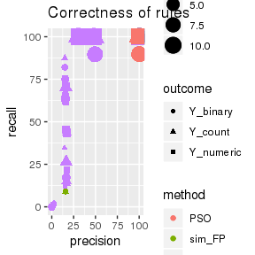

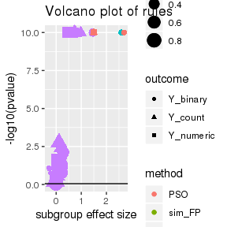

```
##                                   rule   outcome N_ratio  effect_size
##  1:                X1 <= -0.46, X6 = 0 Y_numeric  0.1505  1.502525754
##  2:                X1 <= -0.46, X6 = 0  Y_binary  0.1505  2.602521379
##  3:                X1 <= -0.46, X6 = 0   Y_count  0.1505  1.495766305
##  4:                     X7 = 1, X8 > 6 Y_numeric  0.0855  0.004110973
##  5:                     X7 = 1, X8 > 6  Y_binary  0.0855 -0.174641661
##  6:                     X7 = 1, X8 > 6   Y_count  0.0855 -0.033581120
##  7:                    X1 < -0.4597618 Y_numeric  0.3135  0.716763624
##  8:            X1 < -0.4597618, X6 = 0 Y_numeric  0.1505  1.502525754
##  9:                             X6 = 0 Y_numeric  0.4930  0.467736128
## 10:                   X2 >= -0.4059368 Y_numeric  0.6565  0.059259831
## 11:                           X8 < 4.5 Y_numeric  0.3795  0.054529263
## 12:                      X9 < 0.405671 Y_numeric  0.4170  0.044863427
## 13:                    X10 < 0.1868851 Y_numeric  0.1900  0.043509472
## 14:                   X3 >= -0.2407742 Y_numeric  0.5985  0.024319801
```

[output cut: 87 more lines]